# Chilling Effects: Online Surveillance and Wikipedia Use.

## Abstract

[Penney (2016)](https://papers.ssrn.com/sol3/papers.cfm?abstract_id=2769645) explored whether the widespread publicity about NSA/PRISM surveillance (i.e., the Snowden revelations) in June 2013 was associated with a sharp and sudden decrease in traffic to Wikipedia articles on topics that raise privacy concerns. If so, this change in behavior would be consistent with a chilling effect resulting from mass surveillance. The approach of Penney (2016) is sometimes called an [interrupted time series design](https://ds4ps.org/pe4ps-textbook/docs/p-020-time-series.html), and it is related to the approaches described in section 2.4.3.

To choose the topic keywords, Penney referred to the list used by the US Department of Homeland Security for tracking and monitoring social media. The DHS list categorizes certain search terms into a range of issues, i.e., “Health Concern,” “Infrastructure Security,” and “Terrorism.” For the study group, Penney used the 48 keywords related to “Terrorism” (see appendix table 8). He then aggregated Wikipedia article view counts on a monthly basis for the corresponding 48 Wikipedia articles over a 32-month period from the beginning of January 2012 to the end of August 2014. To strengthen his argument, he also created several comparison groups by tracking article views on other topics.

Now, we are going to replicate and extend [Penney (2016)](https://papers.ssrn.com/sol3/papers.cfm?abstract_id=2769645). All the raw data that you will need for this activity is available from Wikipedia (https://dumps.wikimedia.org/other/pagecounts-raw/). Or we can get it from the R-package wikipediatrend (Meissner and Team 2016).

### Testing `wikipediatrend` package

```r
library(tidyverse)
library(wikipediatrend)
library(lubridate)

# download pageviews from R and Python languages
trend_data <-   wp_trend(
  page = c("R_(programming_language)","Python_(programming_language)"),
  lang = c("en"),
  from = now()-years(2),
  to   = now()
)

# what we have?
head(trend_data) %>%
  knitr::kable()
```

|  | language | article | date | views |
| --- | --- | --- | --- | --- |
| 733 | en | python_(programming_language) | 2019-03-23 | 5082 |
| 1 | en | r_(programming_language) | 2019-03-23 | 2483 |
| 734 | en | python_(programming_language) | 2019-03-24 | 5215 |
| 2 | en | r_(programming_language) | 2019-03-24 | 2545 |
| 735 | en | python_(programming_language) | 2019-03-25 | 7463 |
| 3 | en | r_(programming_language) | 2019-03-25 | 3762 |

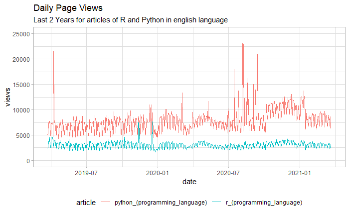

```r
# ploting
trend_data %>%
  ggplot(aes(x=date, y=views, color=article)) +
  geom_line() +
  theme_light() +
  theme(legend.position = "bottom") +
  ylim(0,25000) +
  labs(title="Daily Page Views",subtitle = "Last 2 Years for articles of R and Python in english language")
```

```r
NA
NA
```

### Part A

Read [Penney (2016)](https://papers.ssrn.com/sol3/papers.cfm?abstract_id=2769645) and replicate his figure 2, which shows the page views for “Terrorism”-related pages before and after the Snowden revelations. Interpret the findings.

[figure not shown]

fig2

```r
# loading DHS keywords listed as relating to “terrorism”
keywords <- read.delim("./keywords_table8.txt") %>%
  janitor::clean_names()

# lets see it
head(keywords) %>%
  knitr::kable()
```

| topic_keyword | wikipedia_articles | government_trouble | browser_delete | privacy_sensitive | avoidance |
| --- | --- | --- | --- | --- | --- |
| Al Qaeda | http://en.wikipedia.org/wiki/Al-Qaeda | 2.20 | 2.11 | 2.21 | 2.84 |
| Terrorism | http://en.wikipedia.org/wiki/terrorism | 2.19 | 2.05 | 2.16 | 2.79 |
| Terror | http://en.wikipedia.org/wiki/terror | 1.98 | 1.96 | 2.01 | 2.64 |
| Attack | http://en.wikipedia.org/wiki/attack | 1.92 | 1.91 | 1.92 | 2.56 |
| Iraq | http://en.wikipedia.org/wiki/iraq | 1.60 | 1.74 | 1.76 | 2.25 |
| Afghanistan | http://en.wikipedia.org/wiki/afghanistan | 1.61 | 1.71 | 1.75 | 2.23 |

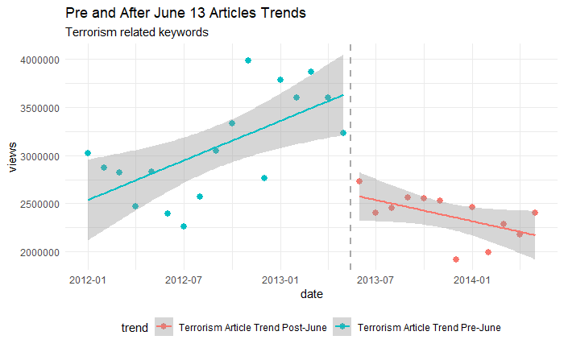

```r
# getting wiki trends

# we can call all keywords at once
# but some keywords aren't return values,
# so let's iterate over each one

# making a "safe version", returning NULL instead of an error
safe_wpTrend <- safely(wp_trend, otherwise = NULL, quiet = T)

# for all keywords
trends <- keywords$wikipedia_articles %>%
  str_extract("(?<=wiki/)(.*)") %>%
  map_df(function(.kw){
    # "...over a 32-month period from the beginning of January 2012 to the end of August 2014..."
    trends_resp <- safe_wpTrend(
      page = .kw,
      lang = c("en"),
      from = "2012-01-01",
      to   = "2014-06-30"
    )
    # will return NULL inst
    return(trends_resp$result)
  })

# "...aggregated Wikipedia article view counts on a monthly basis..."
terrorism_articles <- trends %>%
  filter( views > 0) %>%
  mutate(date = floor_date(date, "month") ) %>%
  group_by(date) %>%
  summarise( views = sum(views) ) %>%
   # ... the Snowden revelations in June 2013...
  mutate( trend = if_else(date < ymd("20130601"), "Terrorism Article Trend Pre-June","Terrorism Article Trend Post-June") ) %>%
  filter( date < ymd(20140601)) %>%
  ungroup()

terrorism_articles %>%
  ggplot(aes(x=date, y=views, color=trend)) +
    geom_point(size=2.5) +
    # ... the Snowden revelations in June 2013...
    geom_vline(xintercept = ymd("20130515"), color="dark grey", linetype="dashed", size=1) +
    geom_smooth(method = "lm", formula = y~x) +
    theme_minimal() +
    theme( legend.position = "bottom") +
    labs(title="Pre and After June 13 Articles Trends", subtitle="Terrorism related keywords")
```

### Part B

Next, replicate figure 4A, which compares the study group (“Terrorism”-related articles) with a comparator group using keywords categorized under “DHS & Other Agencies” from the DHS list (see appendix table 10 and footnote 139). Interpret the findings.

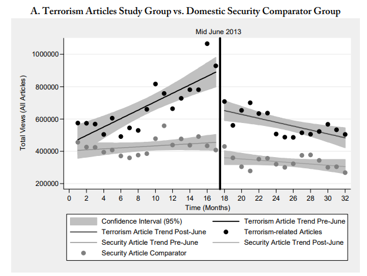

fig 4A

```r
# load table 10
comp_table <- read.delim("./keywords_table10.txt") %>%
  janitor::clean_names()

# lets see
head(comp_table) %>%
  knitr::kable()
```

| topic_keyword | wikipedia_articles |
| --- | --- |
| Department of Homeland Security | https://en.wikipedia.org/wiki/United_States_Department_of_Homeland_Security |
| Federal Emergency Management Agency | https://en.wikipedia.org/wiki/Federal_Emergency_Management_Agency |
| Coast Guard | https://en.wikipedia.org/wiki/Coast_guard |
| Customs and Border Protection | https://en.wikipedia.org/wiki/Customs_and_Border_Protection |
| Border patrol | https://en.wikipedia.org/wiki/Border_Patrol |
| Secret Service | https://en.wikipedia.org/wiki/Secret_Service |

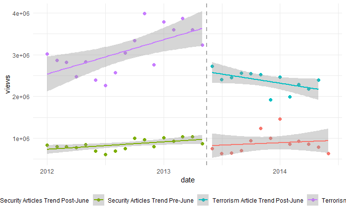

```r
# get the trends
comp_trends <- comp_table$wikipedia_articles %>%
  str_extract("(?<=wiki/)(.*)") %>%
  str_to_lower() %>%
  map_df(function(.kw){
    # "...over a 32-month period from the beginning of January 2012 to the end of August 2014..."
    trends_resp <- safe_wpTrend(
      page = .kw,
      lang = c("en"),
      from = "2012-01-01",
      to   = "2014-06-30"
    )
    # will return NULL inst
    return(trends_resp$result)
  })

# "...aggregated Wikipedia article view counts on a monthly basis..."
sec_articles <- comp_trends %>%
  filter( views > 0 ) %>%
  mutate(date = floor_date(date, "month") ) %>%
  group_by(date) %>%
  summarise( views = sum(views) ) %>%
   # ... the Snowden revelations in June 2013...
  mutate( trend = if_else(date < ymd("20130601"), "Security Articles Trend Pre-June","Security Articles Trend Post-June") ) %>%
  ungroup()

sec_articles %>%
  bind_rows(terrorism_articles) %>%
  ggplot(aes(x=date, y=views, color=trend)) +
    geom_point(size=2) +
    geom_vline(xintercept = ymd("20130515"), color="dark grey", linetype="dashed", size=1) +
    geom_smooth(method = "lm", formula = y~x) +
    theme_minimal() +
    theme( legend.position = "bottom" )
```

## Extra: The Statistical Model

From Jesse Lecy and Federica Fusi’s [Interrupted Time Series](https://ds4ps.org/pe4ps-textbook/docs/p-020-time-series.html#the-statistical-model) we have the following scenario:

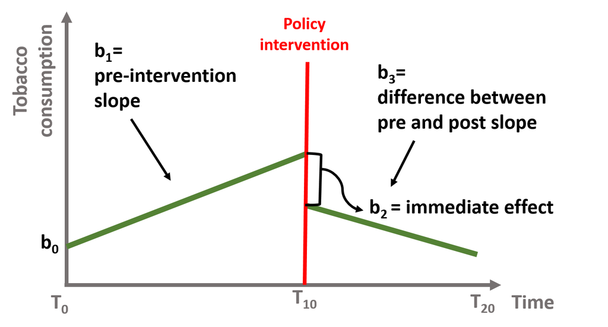

In mathematical terms, it means that the time series equation includes four key coefficients:

$$Y=b_0+b_1T+b_2D+b_3P+e$$

Where: * $Y$ is the outcome variable; * $T$ is a continuous variable which indicates the time (e.g., days, months, years…) passed from the start of the observational period; * $D$ is a dummy variable indicating observation collected before (=0) or after (=1) the policy intervention; * $P$ is a continuous variable indicating time passed since the intervention has occured (before intervention has occured P is equal to 0).

To model this, We would to have a dataset with this format:

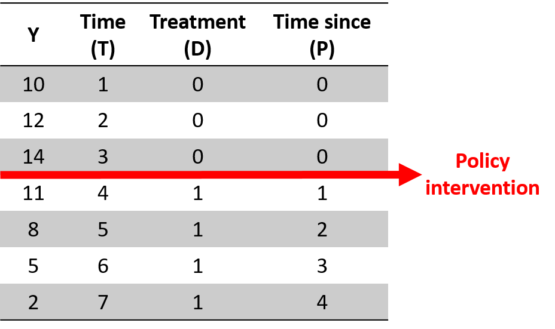

So, let’s build ours

|  | date | Y | T | D | P |
| --- | --- | --- | --- | --- | --- |
| 1 | 2012-01-01 | 3020304 | 1 | 0 | 0 |
| 2 | 2012-02-01 | 2870884 | 2 | 0 | 0 |
| 3 | 2012-03-01 | 2822247 | 3 | 0 | 0 |
| 4 | 2012-04-01 | 2470950 | 4 | 0 | 0 |
| 5 | 2012-05-01 | 2825524 | 5 | 0 | 0 |
| 6 | 2012-06-01 | 2398524 | 6 | 0 | 0 |
| 7 | 2012-07-01 | 2258145 | 7 | 0 | 0 |
| 8 | 2012-08-01 | 2573913 | 8 | 0 | 0 |
| 9 | 2012-09-01 | 3047480 | 9 | 0 | 0 |
| 10 | 2012-10-01 | 3335079 | 10 | 0 | 0 |

[output cut: 20 more lines]

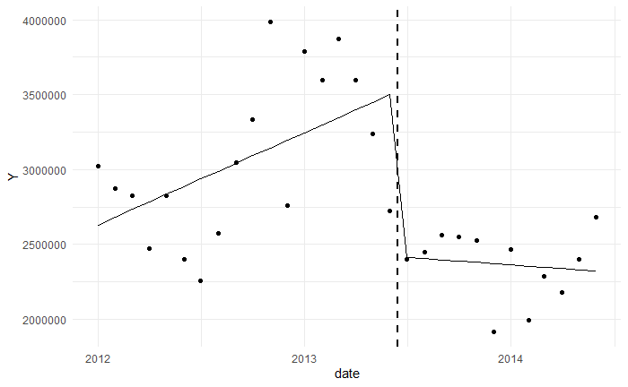

```r
mod1 <- lm( Y ~ T + D + P, data=regr_data )

regr_data %>%
  mutate( pred = predict(mod1) ) %>%
  ggplot(aes(x=date)) +
  geom_point(aes(y=Y)) +
  geom_line(aes(y=pred)) +
  geom_vline(xintercept = ymd(20130615), linetype="dashed", size=1) +
  theme_minimal()
```

```r
summary(mod1)
```

```
Call:
lm(formula = Y ~ T + D + P, data = regr_data)

Residuals:
    Min      1Q  Median      3Q     Max
-775138 -288426   57308  195202  842379

Coefficients:
            Estimate Std. Error t value Pr(>|t|)
(Intercept)  2579316     194174  13.284 4.27e-13 ***
T              51186      17939   2.853  0.00838 **
D           -1078677     301608  -3.576  0.00140 **
P             -59553      37578  -1.585  0.12510
---
Signif. codes:  0 ‘***’ 0.001 ‘**’ 0.01 ‘*’ 0.05 ‘.’ 0.1 ‘ ’ 1

Residual standard error: 394900 on 26 degrees of freedom
Multiple R-squared:  0.5415,    Adjusted R-squared:  0.4886
F-statistic: 10.23 on 3 and 26 DF,  p-value: 0.0001255
```

## Statistical Model: Control Group

Yet from Jesse Lecy and Federica Fusi’s [Interrupted Time Series](https://ds4ps.org/pe4ps-textbook/docs/p-020-time-series.html#validity-threats-control-groups-and-multiple-time-series)

A time series are also subject to threats to internal validity, such as:

- Another event occurred at the same time of the intervention and cause the immediate and sustained effect that we observe;
- Selection processes, as only some individuals are affected by the policy intervention.

To address these issues, you can:

- Use as a control a group that is not subject to the intervention (e.g., students who do not attend the well being class)

This design makes sure that the observed effect is the result of the policy intervention. The data will have two observations per each point in time and will include a dummy variable to differentiate the treatment (=1) and the control (=0). The model has a similar structure but (1) we will include a dummy variable that indicates the treatment and the control group and (2) we will interact the group dummy variable with all 3 time serie coefficients to see if there is a statistically significant difference across the 2 groups.

You can see this in the following equation, where $G$ is a dummy indicating treatment and control group.

$$Y=b_0+b_1∗T+b_2∗D+b_3∗P+b_4∗G+b_5∗G∗T+b_6∗G∗D+b_7∗G∗P$$

```r
regr_control <- comp_trends %>%
  filter( views > 0 ) %>%
  mutate( date = floor_date(date, unit = "month")) %>%
  group_by( date ) %>%
  summarise( views = sum(views) ) %>%
  ungroup() %>%
  mutate(
    T = row_number(),
    D = if_else(T<=18,0,1), # 18 is 2013-06-01
    P = if_else(T<=18,0,T-18)
  ) %>%
  rename( Y=views ) %>%
  mutate( G=0 ) %>%
  bind_rows( mutate(regr_data, G=1 ))

regr_control %>%
  filter( T>14, T<=22) %>%
  arrange(T,D,G,P) %>%
  knitr::kable()
```

| date | Y | T | D | P | G |
| --- | --- | --- | --- | --- | --- |
| 2013-03-01 | 1037816 | 15 | 0 | 0 | 0 |
| 2013-03-01 | 3868814 | 15 | 0 | 0 | 1 |
| 2013-04-01 | 1032305 | 16 | 0 | 0 | 0 |
| 2013-04-01 | 3595489 | 16 | 0 | 0 | 1 |
| 2013-05-01 | 873192 | 17 | 0 | 0 | 0 |
| 2013-05-01 | 3235093 | 17 | 0 | 0 | 1 |
| 2013-06-01 | 747513 | 18 | 0 | 0 | 0 |
| 2013-06-01 | 2725519 | 18 | 0 | 0 | 1 |
| 2013-07-01 | 632677 | 19 | 1 | 1 | 0 |
| 2013-07-01 | 2399060 | 19 | 1 | 1 | 1 |
| 2013-08-01 | 641141 | 20 | 1 | 2 | 0 |
| 2013-08-01 | 2451065 | 20 | 1 | 2 | 1 |
| 2013-09-01 | 705947 | 21 | 1 | 3 | 0 |
| 2013-09-01 | 2559672 | 21 | 1 | 3 | 1 |
| 2013-10-01 | 935108 | 22 | 1 | 4 | 0 |
| 2013-10-01 | 2550031 | 22 | 1 | 4 | 1 |

```r
NA
NA
```

```r
mod2 <- lm( Y ~ T + D + P + G + G*T + G*D + G*P, data=regr_control )

summary(mod2)
```

```
Call:
lm(formula = Y ~ T + D + P + G + G * T + G * D + G * P, data = regr_control)

Residuals:
    Min      1Q  Median      3Q     Max
-775138 -161714   28511  136682  842379

Coefficients:
            Estimate Std. Error t value Pr(>|t|)
(Intercept)   743019     151953   4.890 1.01e-05 ***
T              10751      14038   0.766  0.44724
D             -86033     236027  -0.365  0.71696
P              -4588      29407  -0.156  0.87662
G            1836297     214894   8.545 1.77e-11 ***
T:G            40435      19853   2.037  0.04678 *
D:G          -992644     333792  -2.974  0.00445 **
P:G           -54965      41587  -1.322  0.19206
---
Signif. codes:  0 ‘***’ 0.001 ‘**’ 0.01 ‘*’ 0.05 ‘.’ 0.1 ‘ ’ 1

Residual standard error: 309000 on 52 degrees of freedom
Multiple R-squared:  0.924, Adjusted R-squared:  0.9137
F-statistic: 90.28 on 7 and 52 DF,  p-value: < 2.2e-16
```

[figure not shown]

## Reference

- Penney, Jonathon. 2016. “Chilling Effects: Online Surveillance and Wikipedia Use.” Berkeley Technology Law Journal 31 (1): 117. doi:10.15779/Z38SS13. - https://papers.ssrn.com/sol3/papers.cfm?abstract_id=2769645
- Jesse Lecy and Federica Fusi. “Foundations of Program Evaluation: Regression Tools for Impact Analysis” - https://ds4ps.org/pe4ps-textbook/docs/index.html